Contents: Neural Networks Project

1. Part-A: Solution
2. Part-B: Solution

# Part-A: Solution

- **DOMAIN:** Electronics and Telecommunication
- **CONTEXT:** A communications equipment manufacturing company has a product which is responsible for emitting informative signals.Company wants to build a machine learning model which can help the company to predict the equipment’s signal quality using various parameters.
- **DATA DESCRIPTION:** The data set contains information on various signal tests performed:
1. Parameters: Various measurable signal parameters.
2. Signal_Quality: Final signal strength or quality
- **PROJECT OBJECTIVE:** To build a classifier which can use the given parameters to determine the signal strength or quality.

```python
# Import all the relevant libraries needed to complete the analysis, visualization, modeling and presentation
import pandas as pd
import numpy as np
import os

import seaborn as sns
import matplotlib.pyplot as plt
%matplotlib inline
sns.set_style('darkgrid')
%matplotlib inline

from scipy import stats
from scipy.stats import zscore

from sklearn.preprocessing import LabelEncoder
from sklearn.preprocessing import StandardScaler
from sklearn.preprocessing import MinMaxScaler
from sklearn.preprocessing import RobustScaler
from sklearn import model_selection
from sklearn.model_selection import train_test_split, cross_val_score, GridSearchCV
from sklearn.model_selection import RandomizedSearchCV, StratifiedKFold, KFold
from sklearn.metrics import accuracy_score, confusion_matrix, classification_report
from sklearn.metrics import ConfusionMatrixDisplay, precision_score, recall_score
from sklearn.metrics import precision_recall_curve, roc_curve, auc, roc_auc_score
from sklearn.metrics import plot_precision_recall_curve, average_precision_score
from sklearn.metrics import f1_score, plot_roc_curve

from imblearn.over_sampling import RandomOverSampler
from imblearn.over_sampling import SMOTENC, SMOTE, ADASYN
from imblearn.under_sampling import RandomUnderSampler

import warnings
warnings.filterwarnings("ignore")

# pd.set_option('display.max_columns', None)
# pd.set_option('display.max_rows', None)
```

```python
from google.colab import drive
drive.mount('/content/drive')
```

## 1. Data import and Understanding:

### 1A. Read the ‘Signals.csv’ as DataFrame and import required libraries.

```python
# Read and import the data
df=pd.read_csv('/content/drive/MyDrive/MGL/Project-DL/Signals.csv')
```

```python
df.info()
df.head()
```

```
<class 'pandas.core.frame.DataFrame'>
RangeIndex: 1599 entries, 0 to 1598
Data columns (total 12 columns):
 #   Column           Non-Null Count  Dtype
---  ------           --------------  -----
 0   Parameter 1      1599 non-null   float64
 1   Parameter 2      1599 non-null   float64
 2   Parameter 3      1599 non-null   float64
 3   Parameter 4      1599 non-null   float64
 4   Parameter 5      1599 non-null   float64
 5   Parameter 6      1599 non-null   float64
 6   Parameter 7      1599 non-null   float64
 7   Parameter 8      1599 non-null   float64
 8   Parameter 9      1599 non-null   float64
 9   Parameter 10     1599 non-null   float64
 10  Parameter 11     1599 non-null   float64
 11  Signal_Strength  1599 non-null   int64
dtypes: float64(11), int64(1)
memory usage: 150.0 KB
```

|  | Parameter 1 | Parameter 2 | Parameter 3 | Parameter 4 | Parameter 5 | Parameter 6 | Parameter 7 | Parameter 8 | Parameter 9 | Parameter 10 | Parameter 11 | Signal_Strength |
| --- | --- | --- | --- | --- | --- | --- | --- | --- | --- | --- | --- | --- |
| 0 | 7.4 | 0.70 | 0.00 | 1.9 | 0.076 | 11.0 | 34.0 | 0.9978 | 3.51 | 0.56 | 9.4 | 5 |
| 1 | 7.8 | 0.88 | 0.00 | 2.6 | 0.098 | 25.0 | 67.0 | 0.9968 | 3.20 | 0.68 | 9.8 | 5 |
| 2 | 7.8 | 0.76 | 0.04 | 2.3 | 0.092 | 15.0 | 54.0 | 0.9970 | 3.26 | 0.65 | 9.8 | 5 |
| 3 | 11.2 | 0.28 | 0.56 | 1.9 | 0.075 | 17.0 | 60.0 | 0.9980 | 3.16 | 0.58 | 9.8 | 6 |
| 4 | 7.4 | 0.70 | 0.00 | 1.9 | 0.076 | 11.0 | 34.0 | 0.9978 | 3.51 | 0.56 | 9.4 | 5 |

### 1B. Check for missing values and print percentage for each attribute.

```python
# Percentage of missing values

# df.isnull().sum()
# df.isna().sum()

def missing_check(df):
    total = df.isnull().sum().sort_values(ascending=False)   # total number of null values
    percent = (df.isnull().sum()/df.isnull().count()).sort_values(ascending=False)  # percentage of values that are null
    missing_data = pd.concat([total, percent], axis=1, keys=['Total', 'Percent'])  # putting the above two together
    return missing_data # return the dataframe
missing_check(df)
```

|  | Total | Percent |
| --- | --- | --- |
| Parameter 1 | 0 | 0.0 |
| Parameter 2 | 0 | 0.0 |
| Parameter 3 | 0 | 0.0 |
| Parameter 4 | 0 | 0.0 |
| Parameter 5 | 0 | 0.0 |
| Parameter 6 | 0 | 0.0 |
| Parameter 7 | 0 | 0.0 |
| Parameter 8 | 0 | 0.0 |
| Parameter 9 | 0 | 0.0 |
| Parameter 10 | 0 | 0.0 |
| Parameter 11 | 0 | 0.0 |
| Signal_Strength | 0 | 0.0 |

```python
print(df.Signal_Strength.value_counts())
```

```
5    681
6    638
7    199
4     53
8     18
3     10
Name: Signal_Strength, dtype: int64
```

### 1C. Check for presence of duplicate records in the dataset and impute with appropriate method.

```python
# To take a look at the duplication in the DataFrame as a whole, just call the duplicated() method on
# the DataFrame. It outputs True if an entire row is identical to a previous row.
df.duplicated().sum()
```

```
240
```

```python
# Count the number of non-duplicates
(~df.duplicated()).sum()
```

```
1359
```

```python
# Extract duplicate rows
df.loc[df.duplicated(), :]
```

|  | Parameter 1 | Parameter 2 | Parameter 3 | Parameter 4 | Parameter 5 | Parameter 6 | Parameter 7 | Parameter 8 | Parameter 9 | Parameter 10 | Parameter 11 | Signal_Strength |
| --- | --- | --- | --- | --- | --- | --- | --- | --- | --- | --- | --- | --- |
| 4 | 7.4 | 0.700 | 0.00 | 1.90 | 0.076 | 11.0 | 34.0 | 0.99780 | 3.51 | 0.56 | 9.4 | 5 |
| 11 | 7.5 | 0.500 | 0.36 | 6.10 | 0.071 | 17.0 | 102.0 | 0.99780 | 3.35 | 0.80 | 10.5 | 5 |
| 27 | 7.9 | 0.430 | 0.21 | 1.60 | 0.106 | 10.0 | 37.0 | 0.99660 | 3.17 | 0.91 | 9.5 | 5 |
| 40 | 7.3 | 0.450 | 0.36 | 5.90 | 0.074 | 12.0 | 87.0 | 0.99780 | 3.33 | 0.83 | 10.5 | 5 |
| 65 | 7.2 | 0.725 | 0.05 | 4.65 | 0.086 | 4.0 | 11.0 | 0.99620 | 3.41 | 0.39 | 10.9 | 5 |
| ... | ... | ... | ... | ... | ... | ... | ... | ... | ... | ... | ... | ... |
| 1563 | 7.2 | 0.695 | 0.13 | 2.00 | 0.076 | 12.0 | 20.0 | 0.99546 | 3.29 | 0.54 | 10.1 | 5 |
| 1564 | 7.2 | 0.695 | 0.13 | 2.00 | 0.076 | 12.0 | 20.0 | 0.99546 | 3.29 | 0.54 | 10.1 | 5 |
| 1567 | 7.2 | 0.695 | 0.13 | 2.00 | 0.076 | 12.0 | 20.0 | 0.99546 | 3.29 | 0.54 | 10.1 | 5 |
| 1581 | 6.2 | 0.560 | 0.09 | 1.70 | 0.053 | 24.0 | 32.0 | 0.99402 | 3.54 | 0.60 | 11.3 | 5 |
| 1596 | 6.3 | 0.510 | 0.13 | 2.30 | 0.076 | 29.0 | 40.0 | 0.99574 | 3.42 | 0.75 | 11.0 | 6 |

240 rows × 12 columns

```python
# Percentage of duplicate rows
DuplicatePercent = round((240/1599)*100, 4)
DuplicatePercent
```

```
15.0094
```

```python
df = df.drop_duplicates()
df.info()
```

```
<class 'pandas.core.frame.DataFrame'>
Int64Index: 1359 entries, 0 to 1598
Data columns (total 12 columns):
 #   Column           Non-Null Count  Dtype
---  ------           --------------  -----
 0   Parameter 1      1359 non-null   float64
 1   Parameter 2      1359 non-null   float64
 2   Parameter 3      1359 non-null   float64
 3   Parameter 4      1359 non-null   float64
 4   Parameter 5      1359 non-null   float64
 5   Parameter 6      1359 non-null   float64
 6   Parameter 7      1359 non-null   float64
 7   Parameter 8      1359 non-null   float64
 8   Parameter 9      1359 non-null   float64
 9   Parameter 10     1359 non-null   float64
 10  Parameter 11     1359 non-null   float64
 11  Signal_Strength  1359 non-null   int64
dtypes: float64(11), int64(1)
memory usage: 138.0 KB
```

### 1D. Visualise distribution of the target variable

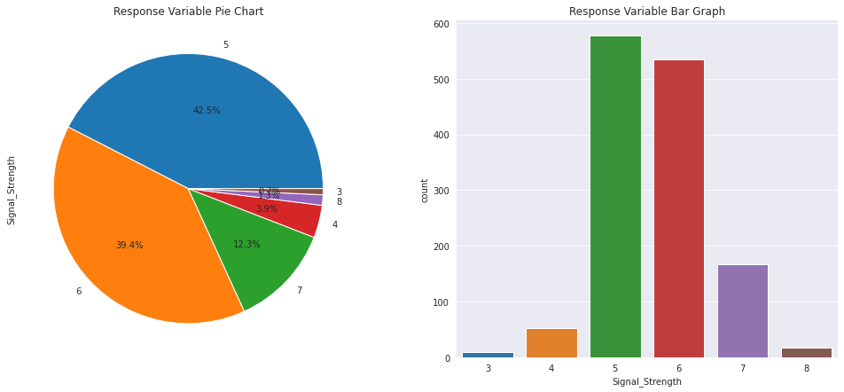

```python
# Understand the target variable and check for imbalanced dataset
f,axes=plt.subplots(1,2,figsize=(17,7))
df['Signal_Strength'].value_counts().plot.pie(autopct='%1.1f%%',ax=axes[0])
sns.countplot('Signal_Strength',data=df,ax=axes[1])
axes[0].set_title('Response Variable Pie Chart')
axes[1].set_title('Response Variable Bar Graph')
plt.show()
```

```python
# Group datapoints by class
df.groupby(["Signal_Strength"]).count()
```

| Signal_Strength | Parameter 1 | Parameter 2 | Parameter 3 | Parameter 4 | Parameter 5 | Parameter 6 | Parameter 7 | Parameter 8 | Parameter 9 | Parameter 10 | Parameter 11 |
| --- | --- | --- | --- | --- | --- | --- | --- | --- | --- | --- | --- |
| 3 | 10 | 10 | 10 | 10 | 10 | 10 | 10 | 10 | 10 | 10 | 10 |
| 4 | 53 | 53 | 53 | 53 | 53 | 53 | 53 | 53 | 53 | 53 | 53 |
| 5 | 577 | 577 | 577 | 577 | 577 | 577 | 577 | 577 | 577 | 577 | 577 |
| 6 | 535 | 535 | 535 | 535 | 535 | 535 | 535 | 535 | 535 | 535 | 535 |
| 7 | 167 | 167 | 167 | 167 | 167 | 167 | 167 | 167 | 167 | 167 | 167 |
| 8 | 17 | 17 | 17 | 17 | 17 | 17 | 17 | 17 | 17 | 17 | 17 |

**Insights from above graphs:**

- Class 5, 6, 7 are dominating total values followed by Class 3, 4, and 8.
- The above graph shows that the data is biased towards data-points having class value as 5 and 6.
- More can be inferred from the pie chart and bar graph above.

**There is big imbalance in the target vector.**

If the imbalanced data is not treated beforehand, then this will degrade the performance of the ML model. Most of the predictions will correspond to the majority class and treat the minority class of features as noise in the data and ignore them. This results in a high bias and low performance of the model.

A widely adopted technique for dealing with highly unbalanced datasets is called re-sampling.

**Two widely used re-sampling methods are:**

- Under-sampling: It is the process where you randomly delete some of the observations from the majority class in order to match the numbers with the minority class.
- Over-sampling: It is the process of generating synthetic data that tries to randomly generate a sample of the attributes from observations in the minority class
- Here we may use oversampling because under-sampling may remove important information from the dataset

### 1E. Share insights from the initial data analysis (at least 2).

```python
# Describe function generates descriptive statistics that summarize the central tendency,
# dispersion and shape of a dataset’s distribution, excluding NaN values.

# This method tells us a lot of things about a dataset. One important thing is that
# the describe() method deals only with numeric values. It doesn't work with any
# categorical values. So if there are any categorical values in a column the describe()
# method will ignore it and display summary for the other columns.
df.describe().T
```

|  | count | mean | std | min | 25% | 50% | 75% | max |
| --- | --- | --- | --- | --- | --- | --- | --- | --- |
| Parameter 1 | 1359.0 | 8.310596 | 1.736990 | 4.60000 | 7.1000 | 7.9000 | 9.20000 | 15.90000 |
| Parameter 2 | 1359.0 | 0.529478 | 0.183031 | 0.12000 | 0.3900 | 0.5200 | 0.64000 | 1.58000 |
| Parameter 3 | 1359.0 | 0.272333 | 0.195537 | 0.00000 | 0.0900 | 0.2600 | 0.43000 | 1.00000 |
| Parameter 4 | 1359.0 | 2.523400 | 1.352314 | 0.90000 | 1.9000 | 2.2000 | 2.60000 | 15.50000 |
| Parameter 5 | 1359.0 | 0.088124 | 0.049377 | 0.01200 | 0.0700 | 0.0790 | 0.09100 | 0.61100 |
| Parameter 6 | 1359.0 | 15.893304 | 10.447270 | 1.00000 | 7.0000 | 14.0000 | 21.00000 | 72.00000 |
| Parameter 7 | 1359.0 | 46.825975 | 33.408946 | 6.00000 | 22.0000 | 38.0000 | 63.00000 | 289.00000 |
| Parameter 8 | 1359.0 | 0.996709 | 0.001869 | 0.99007 | 0.9956 | 0.9967 | 0.99782 | 1.00369 |
| Parameter 9 | 1359.0 | 3.309787 | 0.155036 | 2.74000 | 3.2100 | 3.3100 | 3.40000 | 4.01000 |
| Parameter 10 | 1359.0 | 0.658705 | 0.170667 | 0.33000 | 0.5500 | 0.6200 | 0.73000 | 2.00000 |
| Parameter 11 | 1359.0 | 10.432315 | 1.082065 | 8.40000 | 9.5000 | 10.2000 | 11.10000 | 14.90000 |
| Signal_Strength | 1359.0 | 5.623252 | 0.823578 | 3.00000 | 5.0000 | 6.0000 | 6.00000 | 8.00000 |

**Observations:**

- Parameter 1:
- Mean and Median are nearly equal. Distribution might be normal.
- 75 % of values are less than 9.2, and maximum value is 15.9.
- Parameter 7:
- Mean and median are not equal. Skewness is expected.
- Range of values is large.
- Distribution is not normal because of big SD.

### Quick EDA

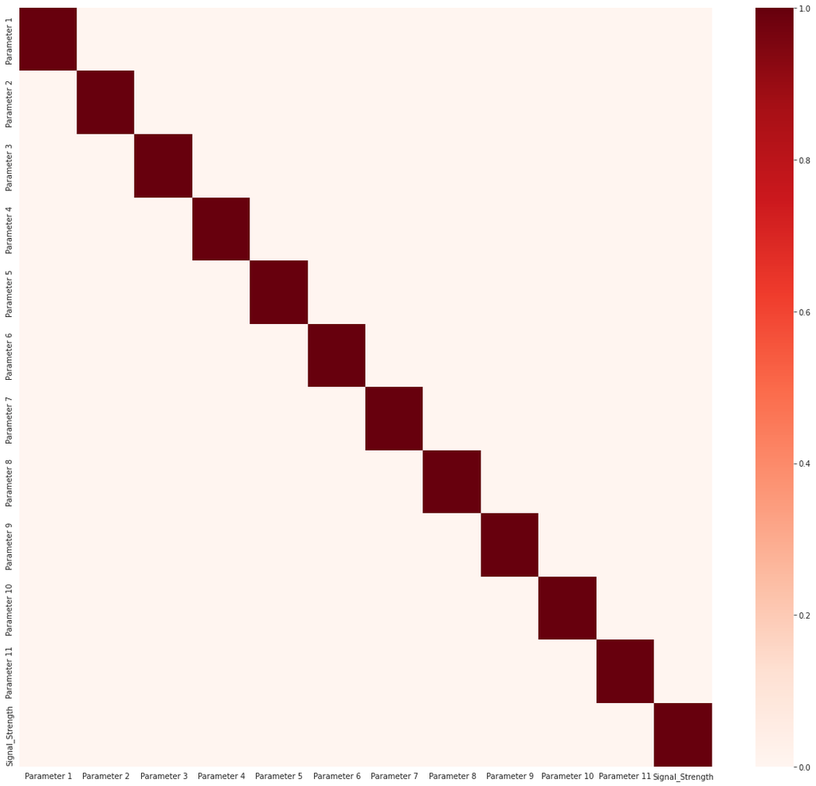

```python
# Check for correlation and consider the features where correlation coeff > 0.7
plt.figure(figsize=(20,18))
corr=df.corr()
sns.heatmap(abs(corr>0.7),cmap="Reds");
```

```python
corr = df.corr()
corr
```

|  | Parameter 1 | Parameter 2 | Parameter 3 | Parameter 4 | Parameter 5 | Parameter 6 | Parameter 7 | Parameter 8 | Parameter 9 | Parameter 10 | Parameter 11 | Signal_Strength |
| --- | --- | --- | --- | --- | --- | --- | --- | --- | --- | --- | --- | --- |
| Parameter 1 | 1.000000 | -0.255124 | 0.667437 | 0.111025 | 0.085886 | -0.140580 | -0.103777 | 0.670195 | -0.686685 | 0.190269 | -0.061596 | 0.119024 |
| Parameter 2 | -0.255124 | 1.000000 | -0.551248 | -0.002449 | 0.055154 | -0.020945 | 0.071701 | 0.023943 | 0.247111 | -0.256948 | -0.197812 | -0.395214 |
| Parameter 3 | 0.667437 | -0.551248 | 1.000000 | 0.143892 | 0.210195 | -0.048004 | 0.047358 | 0.357962 | -0.550310 | 0.326062 | 0.105108 | 0.228057 |
| Parameter 4 | 0.111025 | -0.002449 | 0.143892 | 1.000000 | 0.026656 | 0.160527 | 0.201038 | 0.324522 | -0.083143 | -0.011837 | 0.063281 | 0.013640 |
| Parameter 5 | 0.085886 | 0.055154 | 0.210195 | 0.026656 | 1.000000 | 0.000749 | 0.045773 | 0.193592 | -0.270893 | 0.394557 | -0.223824 | -0.130988 |
| Parameter 6 | -0.140580 | -0.020945 | -0.048004 | 0.160527 | 0.000749 | 1.000000 | 0.667246 | -0.018071 | 0.056631 | 0.054126 | -0.080125 | -0.050463 |
| Parameter 7 | -0.103777 | 0.071701 | 0.047358 | 0.201038 | 0.045773 | 0.667246 | 1.000000 | 0.078141 | -0.079257 | 0.035291 | -0.217829 | -0.177855 |
| Parameter 8 | 0.670195 | 0.023943 | 0.357962 | 0.324522 | 0.193592 | -0.018071 | 0.078141 | 1.000000 | -0.355617 | 0.146036 | -0.504995 | -0.184252 |
| Parameter 9 | -0.686685 | 0.247111 | -0.550310 | -0.083143 | -0.270893 | 0.056631 | -0.079257 | -0.355617 | 1.000000 | -0.214134 | 0.213418 | -0.055245 |
| Parameter 10 | 0.190269 | -0.256948 | 0.326062 | -0.011837 | 0.394557 | 0.054126 | 0.035291 | 0.146036 | -0.214134 | 1.000000 | 0.091621 | 0.248835 |
| Parameter 11 | -0.061596 | -0.197812 | 0.105108 | 0.063281 | -0.223824 | -0.080125 | -0.217829 | -0.504995 | 0.213418 | 0.091621 | 1.000000 | 0.480343 |
| Signal_Strength | 0.119024 | -0.395214 | 0.228057 | 0.013640 | -0.130988 | -0.050463 | -0.177855 | -0.184252 | -0.055245 | 0.248835 | 0.480343 | 1.000000 |

```python
# Make a copy of the dataset and drop the target class for easy EDA
df1=df.copy()
df1.drop(['Signal_Strength'],axis=1,inplace=True)
```

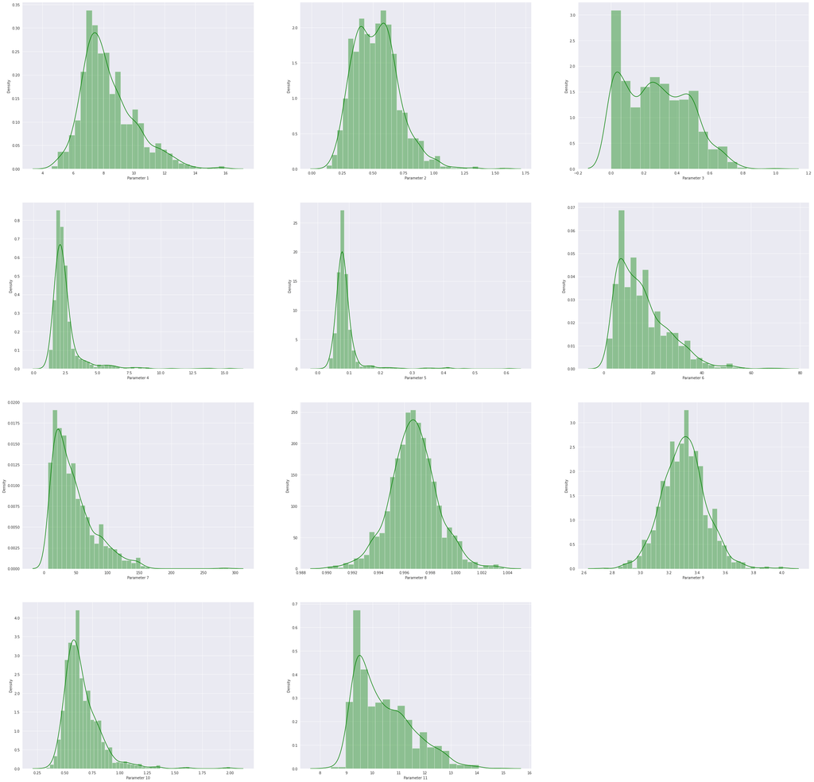

```python
# Density plot to check for the distribution of features
plt.figure(figsize=(40, 40))
col = 1
for i in df1.columns:
    plt.subplot(4, 3, col)
    sns.distplot(df1[i], color = 'g')
    col += 1
```

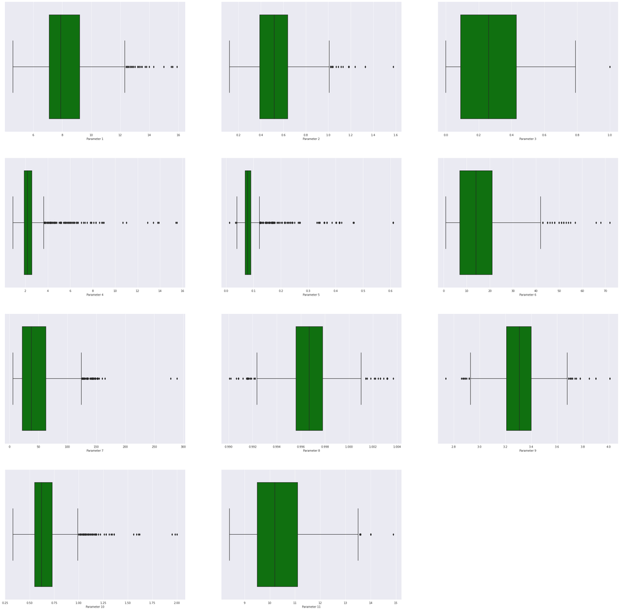

```python
# Use boxplot to check for outliers
plt.figure(figsize=(40, 40))
col = 1
for i in df1.columns:
    plt.subplot(4, 3, col)
    sns.boxplot(df1[i],color='green')
    col += 1
```

```python
# Replace the outliers with median
for i in df1.columns:
    q1 = df1[i].quantile(0.25)
    q3 = df1[i].quantile(0.75)
    iqr = q3 - q1

    low = q1 - 1.5 * iqr
    high = q3 + 1.5 * iqr

    df1.loc[(df1[i] < low) | (df1[i] > high), i] = df1[i].median()
```

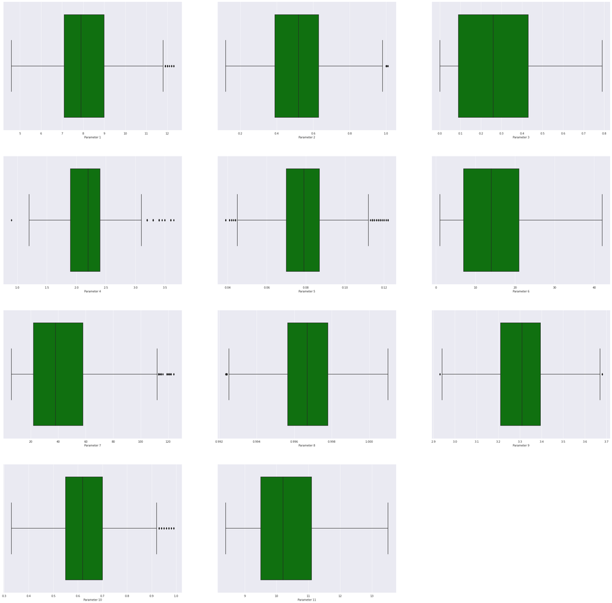

```python
# Situation after removing the outliers with median
plt.figure(figsize=(40, 40))
col = 1
for i in df1.columns:
    plt.subplot(4, 3, col)
    sns.boxplot(df1[i],color='green')
    col += 1
```

```python
# Combine the dataset
y=df['Signal_Strength']
df1=pd.concat([df1,y],axis=1)

df1.info()
```

```
<class 'pandas.core.frame.DataFrame'>
Int64Index: 1359 entries, 0 to 1598
Data columns (total 12 columns):
 #   Column           Non-Null Count  Dtype
---  ------           --------------  -----
 0   Parameter 1      1359 non-null   float64
 1   Parameter 2      1359 non-null   float64
 2   Parameter 3      1359 non-null   float64
 3   Parameter 4      1359 non-null   float64
 4   Parameter 5      1359 non-null   float64
 5   Parameter 6      1359 non-null   float64
 6   Parameter 7      1359 non-null   float64
 7   Parameter 8      1359 non-null   float64
 8   Parameter 9      1359 non-null   float64
 9   Parameter 10     1359 non-null   float64
 10  Parameter 11     1359 non-null   float64
 11  Signal_Strength  1359 non-null   int64
dtypes: float64(11), int64(1)
memory usage: 170.3 KB
```

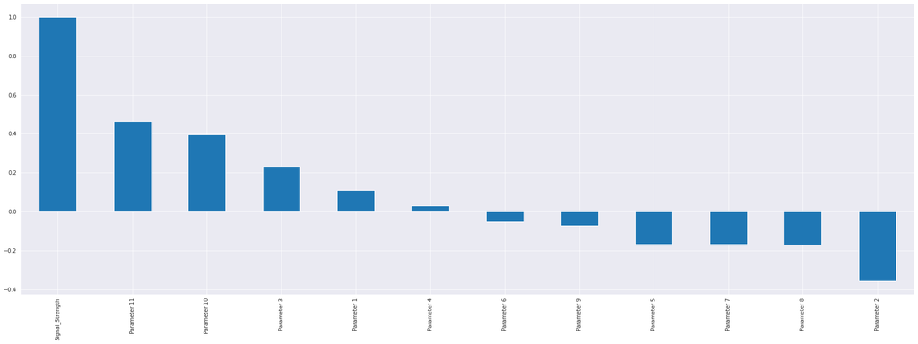

```python
# Correlation of "Signal_Strength" with other features
# Open image in a new tab for details
plt.figure(figsize=(30,10))
df1.corr()['Signal_Strength'].sort_values(ascending = False).plot(kind='bar')
```

## 2. Data preprocessing:

### 2A. Split the data into X & Y.

```python
# Create the features matrix and target vector
X=df1.drop(['Signal_Strength'], axis=1)
y=df1['Signal_Strength']
```

### 2B. Split the data into train & test with 70:30 proportion.

```python
# Split the data for training and testing
from sklearn.model_selection import train_test_split
X_train, X_test, y_train, y_test = train_test_split(X, y, test_size=0.3, random_state=0)
```

### 2C. Print shape of all the 4 variables and verify if train and test data is in sync.

```python
print(X_train.shape,X_test.shape)
print(y_train.shape,y_test.shape)
```

```
(951, 11) (408, 11)
(951,) (408,)
```

### 2D. Normalise the train and test data with appropriate method.

```python
# Using different scaling methods:
# scaler = RobustScaler()
# scaler = MinMaxScaler()
scaler = StandardScaler()
# mydata = mydata.apply(zscore)

X_train = scaler.fit_transform(X_train)
X_test = scaler.transform(X_test)

# X_train = X_train.apply(zscore)
# X_test = X_test.apply(zscore)
```

### 2E. Transform Labels into format acceptable by Neural Network.

```python
# Encoding is used for categorical data
# We can consider 3,4,5,6,7,8 as categorical
# Use one hot encoding
y_train = pd.get_dummies(y_train)
y_test = pd.get_dummies(y_test)
```

```python
y_train.head()
```

|  | 3 | 4 | 5 | 6 | 7 | 8 |
| --- | --- | --- | --- | --- | --- | --- |
| 1171 | 0 | 0 | 0 | 1 | 0 | 0 |
| 1015 | 0 | 0 | 0 | 1 | 0 | 0 |
| 1379 | 0 | 0 | 0 | 1 | 0 | 0 |
| 18 | 0 | 1 | 0 | 0 | 0 | 0 |
| 1007 | 0 | 0 | 0 | 0 | 1 | 0 |

```python
y_test.head()
```

|  | 3 | 4 | 5 | 6 | 7 | 8 |
| --- | --- | --- | --- | --- | --- | --- |
| 1133 | 0 | 0 | 0 | 0 | 1 | 0 |
| 760 | 0 | 0 | 1 | 0 | 0 | 0 |
| 1173 | 0 | 0 | 0 | 1 | 0 | 0 |
| 1079 | 0 | 0 | 0 | 0 | 1 | 0 |
| 935 | 0 | 0 | 0 | 1 | 0 | 0 |

```python
print(X_train.shape,X_test.shape)
print(y_train.shape,y_test.shape)
```

```
(951, 11) (408, 11)
(951, 6) (408, 6)
```

## 3. Model Training & Evaluation using Neural Network

- 3A. Design a Neural Network to train a classifier.
- 3B. Train the classifier using previously designed Architecture.
- 3C. Plot 2 separate visuals.
- i. Training Loss and Validation Loss
- ii. Training Accuracy and Validation Accuracy
- 3D. Design new architecture/update existing architecture in attempt to improve the performance of the model.
- 3E. Plot visuals as in Q3.C and share insights about difference observed in both the models.

```python
import tensorflow as tf
from tensorflow.keras.models import Sequential
from tensorflow.keras.layers import Dense
from tensorflow.keras.layers import Dense, Input, Dropout, BatchNormalization
from tensorflow.keras.wrappers.scikit_learn import KerasClassifier
import random
from tensorflow.keras import backend
random.seed(1)
np.random.seed(1)
tf.random.set_seed(1)
```

### Model-1: Base model

```python
backend.clear_session()
#Fixing the seed for random number generators so that we can ensure we receive the same output everytime
np.random.seed(42)
import random
random.seed(42)
tf.random.set_seed(42)
```

```python
# Initializing the ANN
model1 = Sequential()
# Input layer
model1.add(Dense(activation = 'relu', input_dim = 11, units=64))
#Add 1st hidden layer
model1.add(Dense(32, activation='relu'))
# Adding the output layer
model1.add(Dense(6, activation = 'sigmoid'))
```

```python
# Create optimizer with default learning rate
# Compile the model
model1.compile(optimizer='SGD', loss='categorical_crossentropy', metrics=['accuracy'])
```

```python
model1.summary()
```

```
Model: "sequential"
_________________________________________________________________
 Layer (type)                Output Shape              Param #
=================================================================
 dense (Dense)               (None, 64)                768

 dense_1 (Dense)             (None, 32)                2080

 dense_2 (Dense)             (None, 6)                 198

=================================================================
Total params: 3,046
Trainable params: 3,046
Non-trainable params: 0
_________________________________________________________________
```

```python
history1=model1.fit(X_train, y_train,
          validation_split=0.2,
          epochs=50,
          batch_size=64,verbose=1)
```

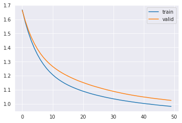

```python
# Capturing learning history per epoch
hist  = pd.DataFrame(history1.history)
hist['epoch'] = history1.epoch

# Plotting accuracy at different epochs
plt.plot(hist['loss'])
plt.plot(hist['val_loss'])
plt.legend(("train" , "valid") , loc =0)

# Printing results
results = model1.evaluate(X_test, y_test)
```

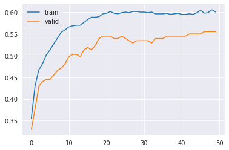

```python
# Capturing learning history per epoch
hist  = pd.DataFrame(history1.history)
hist['epoch'] = history1.epoch

# Plotting accuracy at different epochs
plt.plot(hist['accuracy'])
plt.plot(hist['val_accuracy'])
plt.legend(("train" , "valid") , loc =0)

# Printing results
results = model1.evaluate(X_test, y_test)
```

```python
y_pred=model1.predict(X_test)
y_pred
```

```
array([[0.18235818, 0.31053436, 0.5687744 , 0.76309866, 0.5471687 ,
        0.1997333 ],
       [0.09896776, 0.30970627, 0.9103076 , 0.6985566 , 0.22493279,
        0.08294086],
       [0.08206265, 0.4162583 , 0.92127985, 0.8337923 , 0.24692819,
        0.0628167 ],
       ...,
       [0.07567943, 0.13723624, 0.4403985 , 0.8286709 , 0.81586576,
        0.17465219],
       [0.20294283, 0.3092754 , 0.81379324, 0.7241249 , 0.42468822,
        0.26315117],
       [0.1773378 , 0.39544532, 0.7817832 , 0.72599876, 0.3695721 ,
        0.1421604 ]], dtype=float32)
```

```
Loss and Accuracy on Training data: [0.9884610176086426, 0.5962145328521729]
Loss and Accuracy on Test data: [1.0628232955932617, 0.5563725233078003]

Classification Report:
               precision    recall  f1-score   support

           0       0.00      0.00      0.00         5
           1       0.00      0.00      0.00        11
           2       0.63      0.75      0.69       176
           3       0.48      0.62      0.54       153
           4       0.00      0.00      0.00        60
           5       0.00      0.00      0.00         3

    accuracy                           0.56       408
   macro avg       0.19      0.23      0.20       408
weighted avg       0.45      0.56      0.50       408

Confusion Matrix Chart:
```

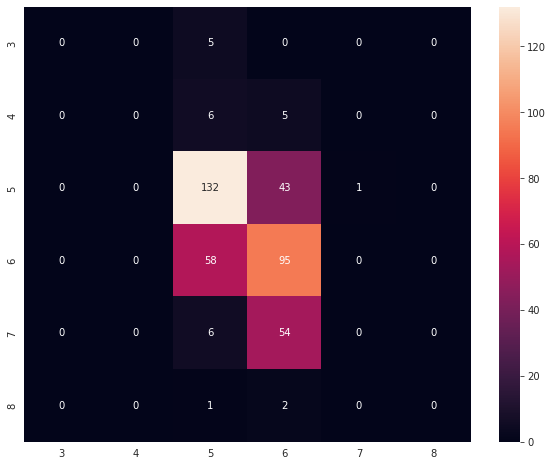

```python
# Classification Accuracy
print('Loss and Accuracy on Training data:',model1.evaluate(X_train, y_train))
print('Loss and Accuracy on Test data:',model1.evaluate(X_test, y_test))
print()

# Classification Report
print("Classification Report:\n",classification_report(y_test.values.argmax(axis=1), y_pred.argmax(axis=1)))

# Confusion Matrix
print("Confusion Matrix Chart:")
cm = confusion_matrix(y_test.values.argmax(axis=1), y_pred.argmax(axis=1), labels=[0,1,2,3,4,5])
df_cm = pd.DataFrame(cm, index = [i for i in ['3','4','5','6','7','8']],
                  columns = [i for i in ['3','4','5','6','7','8']])
plt.figure(figsize = (10,8))
sns.heatmap(df_cm, annot=True, fmt='g')
plt.show()
```

**Evaluation metrics allow us to estimate errors to determine how well our models are performing:**

> Accuracy: ratio of correct predictions over total predictions.

> Precision: how often the classifier is correct when it predicts positive.

> Recall: how often the classifier is correct for all positive instances.

> F-Score: single measurement to combine precision and recall.

**Considering the Class Recall, Precision and F1 Score as the most important parameters to decide the best model for this problem. We have the highest values in Model-3 and Model-6 here. Please refer the Model-3 and Model-6 for the same.**

### Model-2: Improving Base Model

Let's try to change the optimizer, tune the decision threshold, increase the layers and configure some other hyperparameters accordingly, in order to improve the model's performance.

```python
backend.clear_session()
np.random.seed(42)
import random
random.seed(42)
tf.random.set_seed(42)
```

```python
model2 = Sequential()

model2.add(Dense(256,activation='relu',kernel_initializer='he_uniform',input_dim = X_train.shape[1]))
# Adding the hidden and output layers
model2.add(Dense(128,activation='relu',kernel_initializer='he_uniform'))
model2.add(Dense(64,activation='relu',kernel_initializer='he_uniform'))
model2.add(Dense(32,activation='relu',kernel_initializer='he_uniform'))
model2.add(Dense(6, activation = 'sigmoid'))
# Compiling the ANN with Adam optimizer and binary cross entropy loss function
optimizer = tf.keras.optimizers.Adam(0.001)
model2.compile(loss='categorical_crossentropy',optimizer=optimizer,metrics=['accuracy'])
```

```python
model2.summary()
```

```
Model: "sequential"
_________________________________________________________________
 Layer (type)                Output Shape              Param #
=================================================================
 dense (Dense)               (None, 256)               3072

 dense_1 (Dense)             (None, 128)               32896

 dense_2 (Dense)             (None, 64)                8256

 dense_3 (Dense)             (None, 32)                2080

 dense_4 (Dense)             (None, 6)                 198

=================================================================
Total params: 46,502
Trainable params: 46,502
Non-trainable params: 0
_________________________________________________________________
```

```python
history2 = model2.fit(X_train,y_train,batch_size=64,epochs=50,verbose=1,validation_split = 0.2)
```

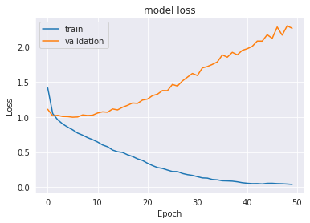

```python
#Plotting Train Loss vs Validation Loss
plt.plot(history2.history['loss'])
plt.plot(history2.history['val_loss'])
plt.title('model loss')
plt.ylabel('Loss')
plt.xlabel('Epoch')
plt.legend(['train', 'validation'], loc='upper left')
plt.show()
```

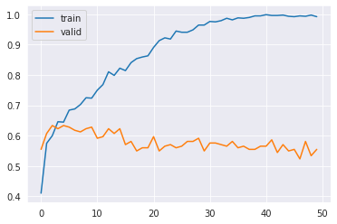

```python
# Capturing learning history per epoch
hist  = pd.DataFrame(history2.history)
hist['epoch'] = history2.epoch

# Plotting accuracy at different epochs
plt.plot(hist['accuracy'])
plt.plot(hist['val_accuracy'])
plt.legend(("train" , "valid") , loc =0)

# Printing results
results = model1.evaluate(X_test, y_test)
```

```python
y_pred=model2.predict(X_test)
y_pred
```

```
array([[6.45854860e-04, 2.27996036e-01, 1.69372018e-02, 9.90134776e-01,
        9.95504200e-01, 2.51418203e-01],
       [3.40988040e-02, 2.47723088e-02, 9.99925971e-01, 9.98209238e-01,
        2.41229864e-05, 4.82622227e-06],
       [9.18987989e-02, 2.49558613e-02, 9.99542594e-01, 9.94384706e-01,
        1.14321709e-04, 2.87103194e-05],
       ...,
       [1.11958543e-04, 7.00416649e-03, 4.22769845e-01, 9.82074976e-01,
        9.99997914e-01, 9.94693100e-01],
       [1.73956335e-01, 4.50077951e-02, 9.99987483e-01, 3.11890095e-01,
        1.58660579e-04, 1.02231985e-04],
       [6.20636344e-03, 6.72178090e-01, 9.98321474e-01, 7.62048602e-01,
        1.03048328e-02, 9.20392107e-04]], dtype=float32)
```

```
Loss and Accuracy on Training data: [0.48282817006111145, 0.9074658155441284]
Loss and Accuracy on Test data: [2.6577725410461426, 0.4828431308269501]

Classification Report:
               precision    recall  f1-score   support

           0       0.00      0.00      0.00         5
           1       0.09      0.09      0.09        11
           2       0.59      0.62      0.61       176
           3       0.43      0.43      0.43       153
           4       0.43      0.33      0.38        60
           5       0.00      0.00      0.00         3

    accuracy                           0.48       408
   macro avg       0.26      0.25      0.25       408
weighted avg       0.48      0.48      0.48       408

Confusion Matrix Chart:
```

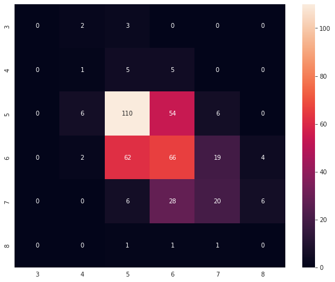

```python
# Classification Accuracy
print('Loss and Accuracy on Training data:',model2.evaluate(X_train, y_train))
print('Loss and Accuracy on Test data:',model2.evaluate(X_test, y_test))
print()

# Classification Report
print("Classification Report:\n",classification_report(y_test.values.argmax(axis=1), y_pred.argmax(axis=1)))

# Confusion Matrix
print("Confusion Matrix Chart:")
cm = confusion_matrix(y_test.values.argmax(axis=1), y_pred.argmax(axis=1), labels=[0,1,2,3,4,5])
df_cm = pd.DataFrame(cm, index = [i for i in ['3','4','5','6','7','8']],
                  columns = [i for i in ['3','4','5','6','7','8']])
plt.figure(figsize = (10,8))
sns.heatmap(df_cm, annot=True, fmt='g')
plt.show()
```

### Model-3: Using Batch Normalization technique

```python
backend.clear_session()
np.random.seed(42)
import random
random.seed(42)
tf.random.set_seed(42)
```

```python
model3 = Sequential()
model3.add(Dense(128,activation='relu',input_dim = X_train.shape[1]))
model3.add(BatchNormalization())
model3.add(Dense(64,activation='relu',kernel_initializer='he_uniform'))
model3.add(BatchNormalization())
model3.add(Dense(32,activation='relu',kernel_initializer='he_uniform'))
model3.add(Dense(6, activation = 'sigmoid'))
```

```python
model3.summary()
```

```
Model: "sequential"
_________________________________________________________________
 Layer (type)                Output Shape              Param #
=================================================================
 dense (Dense)               (None, 128)               1536

 batch_normalization (BatchN  (None, 128)              512
 ormalization)

 dense_1 (Dense)             (None, 64)                8256

 batch_normalization_1 (Batc  (None, 64)               256
 hNormalization)

 dense_2 (Dense)             (None, 32)                2080

 dense_3 (Dense)             (None, 6)                 198

=================================================================
Total params: 12,838
Trainable params: 12,454
Non-trainable params: 384
_________________________________________________________________
```

```python
optimizer = tf.keras.optimizers.Adam(0.001)
model3.compile(loss='categorical_crossentropy',optimizer=optimizer,metrics=['accuracy'])
```

```python
history3 = model3.fit(X_train,y_train,batch_size=64,epochs=50,verbose=1,validation_split = 0.2)
```

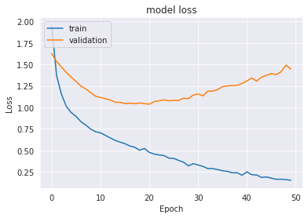

```python
#Plotting Train Loss vs Validation Loss
plt.plot(history3.history['loss'])
plt.plot(history3.history['val_loss'])
plt.title('model loss')
plt.ylabel('Loss')
plt.xlabel('Epoch')
plt.legend(['train', 'validation'], loc='upper left')
plt.show()
```

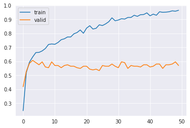

```python
# Capturing learning history per epoch
hist  = pd.DataFrame(history3.history)
hist['epoch'] = history3.epoch

# Plotting accuracy at different epochs
plt.plot(hist['accuracy'])
plt.plot(hist['val_accuracy'])
plt.legend(("train" , "valid") , loc =0)

# Printing results
results = model1.evaluate(X_test, y_test)
```

```python
y_pred=model3.predict(X_test)
y_pred
```

```
array([[7.9881689e-03, 2.2421835e-02, 4.6880930e-03, 9.6786284e-01,
        9.6740472e-01, 3.2359052e-01],
       [7.8335859e-02, 1.1296203e-02, 9.7840983e-01, 9.2554986e-01,
        1.0886361e-01, 1.1886075e-01],
       [1.5368027e-02, 4.8065845e-02, 9.5700532e-01, 8.7546074e-01,
        5.5405259e-04, 1.6147865e-02],
       ...,
       [2.4001652e-02, 3.6817521e-02, 4.3608274e-02, 8.1541169e-01,
        9.9469000e-01, 8.3213830e-01],
       [1.2916172e-01, 2.3435471e-03, 9.4066054e-01, 1.4043047e-01,
        1.1885194e-02, 4.5958828e-02],
       [4.4094878e-03, 6.2043848e-03, 6.0404605e-01, 9.6136010e-01,
        8.7246984e-02, 5.6812815e-02]], dtype=float32)
```

```
Loss and Accuracy on Training data: [0.3843594491481781, 0.9001051783561707]
Loss and Accuracy on Test data: [1.8338216543197632, 0.5343137383460999]

Classification Report:
               precision    recall  f1-score   support

           0       0.00      0.00      0.00         5
           1       0.09      0.09      0.09        11
           2       0.62      0.65      0.64       176
           3       0.50      0.54      0.52       153
           4       0.42      0.35      0.38        60
           5       0.00      0.00      0.00         3

    accuracy                           0.53       408
   macro avg       0.27      0.27      0.27       408
weighted avg       0.52      0.53      0.53       408

Confusion Matrix Chart:
```

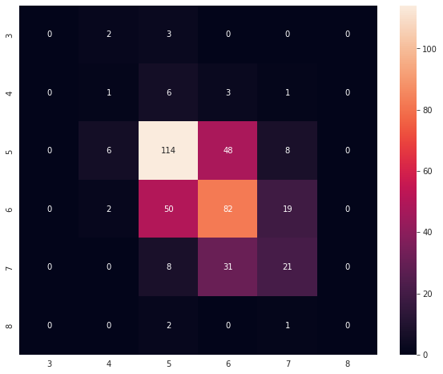

```python
# Classification Accuracy
print('Loss and Accuracy on Training data:',model3.evaluate(X_train, y_train))
print('Loss and Accuracy on Test data:',model3.evaluate(X_test, y_test))
print()

# Classification Report
print("Classification Report:\n",classification_report(y_test.values.argmax(axis=1), y_pred.argmax(axis=1)))

# Confusion Matrix
print("Confusion Matrix Chart:")
cm = confusion_matrix(y_test.values.argmax(axis=1), y_pred.argmax(axis=1), labels=[0,1,2,3,4,5])
df_cm = pd.DataFrame(cm, index = [i for i in ['3','4','5','6','7','8']],
                  columns = [i for i in ['3','4','5','6','7','8']])
plt.figure(figsize = (10,8))
sns.heatmap(df_cm, annot=True, fmt='g')
plt.show()
```

### Model-4: Using the Dropout technique

```python
backend.clear_session()
np.random.seed(42)
import random
random.seed(42)
tf.random.set_seed(42)
```

```python
model4 = Sequential()
model4.add(Dense(256,activation='relu',input_dim = X_train.shape[1]))
model4.add(Dropout(0.2))
model4.add(Dense(128,activation='relu'))
model4.add(Dropout(0.2))
model4.add(Dense(64,activation='relu'))
model4.add(Dropout(0.2))
model4.add(Dense(32,activation='relu'))
model4.add(Dense(6, activation = 'sigmoid'))
```

```python
model4.summary()
```

```
Model: "sequential"
_________________________________________________________________
 Layer (type)                Output Shape              Param #
=================================================================
 dense (Dense)               (None, 256)               3072

 dropout (Dropout)           (None, 256)               0

 dense_1 (Dense)             (None, 128)               32896

 dropout_1 (Dropout)         (None, 128)               0

 dense_2 (Dense)             (None, 64)                8256

 dropout_2 (Dropout)         (None, 64)                0

 dense_3 (Dense)             (None, 32)                2080

 dense_4 (Dense)             (None, 6)                 198

=================================================================
Total params: 46,502
Trainable params: 46,502
Non-trainable params: 0
_________________________________________________________________
```

```python
optimizer = tf.keras.optimizers.Adam(0.001)
model4.compile(loss='categorical_crossentropy',optimizer=optimizer,metrics=['accuracy'])
```

```python
history4 = model4.fit(X_train,y_train,batch_size=64,epochs=50,verbose=1,validation_split = 0.2)
```

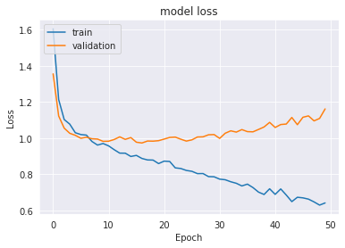

```python
#Plotting Train Loss vs Validation Loss
plt.plot(history4.history['loss'])
plt.plot(history4.history['val_loss'])
plt.title('model loss')
plt.ylabel('Loss')
plt.xlabel('Epoch')
plt.legend(['train', 'validation'], loc='upper left')
plt.show()
```

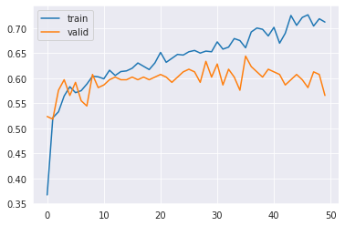

```python
# Capturing learning history per epoch
hist  = pd.DataFrame(history4.history)
hist['epoch'] = history4.epoch

# Plotting accuracy at different epochs
plt.plot(hist['accuracy'])
plt.plot(hist['val_accuracy'])
plt.legend(("train" , "valid") , loc =0)

# Printing results
results = model1.evaluate(X_test, y_test)
```

```python
y_pred=model4.predict(X_test)
y_pred
```

```
array([[9.0499213e-03, 3.1040110e-02, 2.6719135e-01, 9.5943511e-01,
        9.6848470e-01, 6.2159300e-01],
       [1.0812690e-02, 2.1456948e-01, 9.9535096e-01, 9.6594578e-01,
        4.8493989e-02, 1.9986134e-04],
       [6.3623257e-02, 4.1025412e-01, 9.7965622e-01, 9.6214253e-01,
        1.3324233e-02, 2.2761690e-04],
       ...,
       [3.5059385e-03, 7.1502388e-03, 1.2351957e-01, 9.7098178e-01,
        9.9103671e-01, 9.5643228e-01],
       [3.1627916e-02, 1.5734640e-01, 9.9461395e-01, 8.3550853e-01,
        2.5590457e-02, 2.6593043e-04],
       [2.1018496e-02, 3.6447677e-01, 9.6433038e-01, 8.6634487e-01,
        1.2278101e-01, 5.2900789e-03]], dtype=float32)
```

```
Loss and Accuracy on Training data: [0.6318293213844299, 0.7486855983734131]
Loss and Accuracy on Test data: [1.3402303457260132, 0.5098039507865906]

Classification Report:
               precision    recall  f1-score   support

           0       0.00      0.00      0.00         5
           1       0.09      0.09      0.09        11
           2       0.61      0.72      0.66       176
           3       0.47      0.43      0.45       153
           4       0.37      0.25      0.30        60
           5       0.00      0.00      0.00         3

    accuracy                           0.51       408
   macro avg       0.26      0.25      0.25       408
weighted avg       0.49      0.51      0.50       408

Confusion Matrix Chart:
```

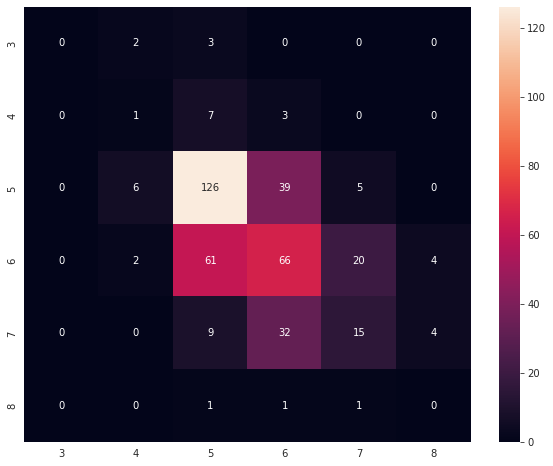

```python
# Classification Accuracy
print('Loss and Accuracy on Training data:',model4.evaluate(X_train, y_train))
print('Loss and Accuracy on Test data:',model4.evaluate(X_test, y_test))
print()

# Classification Report
print("Classification Report:\n",classification_report(y_test.values.argmax(axis=1), y_pred.argmax(axis=1)))

# Confusion Matrix
print("Confusion Matrix Chart:")
cm = confusion_matrix(y_test.values.argmax(axis=1), y_pred.argmax(axis=1), labels=[0,1,2,3,4,5])
df_cm = pd.DataFrame(cm, index = [i for i in ['3','4','5','6','7','8']],
                  columns = [i for i in ['3','4','5','6','7','8']])
plt.figure(figsize = (10,8))
sns.heatmap(df_cm, annot=True, fmt='g')
plt.show()
```

### Model-5: Hyperparameter Tuning

Some important hyperparameters to look out for while optimizing neural networks are:

- Type of Architecture
- Number of Layers
- Number of Neurons in a layer
- Regularization hyperparameters
- Learning Rate
- Type of Optimizer
- Dropout Rate

```python
backend.clear_session()
np.random.seed(42)
import random
random.seed(42)
tf.random.set_seed(42)
```

```python
def create_model_v5(lr,batch_size):
    np.random.seed(1337)
    model = Sequential()
    model.add(Dense(256,activation='relu',input_dim = X_train.shape[1]))
    model.add(Dropout(0.3))
    #model.add(Dense(128,activation='relu',kernel_initializer='he_uniform'))
    model.add(Dense(128,activation='relu'))
    model.add(Dropout(0.3))
    model.add(Dense(64,activation='relu'))
    model.add(Dropout(0.2))
    #model.add(Dense(32,activation='relu',kernel_initializer='he_uniform'))
    #model.add(Dropout(0.3))
    model.add(Dense(32,activation='relu'))
    model.add(Dense(6, activation='sigmoid'))

    #compile model
    optimizer = tf.keras.optimizers.Adam(learning_rate=lr)
    model.compile(optimizer = optimizer,loss = 'categorical_crossentropy', metrics = ['accuracy'])
    return model
```

```python
model5 = KerasClassifier(build_fn=create_model_v5, verbose=1)

params = {'batch_size':[32, 64, 128],
          'lr':[0.01,0.1,0.001]}

gs = RandomizedSearchCV(estimator=model5, param_distributions=params, cv=5, verbose=10, n_jobs=2, random_state=0)
gs.fit(X_train, y_train)
```

```
Fitting 5 folds for each of 9 candidates, totalling 45 fits
```

```
RandomizedSearchCV(cv=5,
                   estimator=<keras.wrappers.scikit_learn.KerasClassifier object at 0x7feca6aeded0>,
                   n_jobs=2,
                   param_distributions={'batch_size': [32, 64, 128],
                                        'lr': [0.01, 0.1, 0.001]},
                   random_state=0, verbose=10)
```

```python
pd.DataFrame({'param': gs.cv_results_["params"],
              'score mean': gs.cv_results_["mean_test_score"],
              'score s.d.': gs.cv_results_["std_test_score"],
              'rank': gs.cv_results_["rank_test_score"]})
```

|  | param | score mean | score s.d. | rank |
| --- | --- | --- | --- | --- |
| 0 | {'lr': 0.01, 'batch_size': 32} | 0.535189 | 0.026088 | 3 |
| 1 | {'lr': 0.1, 'batch_size': 32} | 0.433188 | 0.053994 | 8 |
| 2 | {'lr': 0.001, 'batch_size': 32} | 0.561455 | 0.051205 | 2 |
| 3 | {'lr': 0.01, 'batch_size': 64} | 0.565627 | 0.048625 | 1 |
| 4 | {'lr': 0.1, 'batch_size': 64} | 0.451000 | 0.069183 | 6 |
| 5 | {'lr': 0.001, 'batch_size': 64} | 0.423814 | 0.071540 | 9 |
| 6 | {'lr': 0.01, 'batch_size': 128} | 0.533006 | 0.070444 | 4 |
| 7 | {'lr': 0.1, 'batch_size': 128} | 0.439438 | 0.062531 | 7 |
| 8 | {'lr': 0.001, 'batch_size': 128} | 0.466812 | 0.059084 | 5 |

```python
print('Best Parameters:', gs.best_params_, 'mean score: ', gs.best_score_, sep='\n')
```

```
Best Parameters:
{'lr': 0.01, 'batch_size': 64}
mean score:
0.5656268954277038
```

```python
model5=create_model_v5(batch_size=32, lr=0.01)

model5.summary()
```

```
Model: "sequential_1"
_________________________________________________________________
 Layer (type)                Output Shape              Param #
=================================================================
 dense_5 (Dense)             (None, 256)               3072

 dropout_3 (Dropout)         (None, 256)               0

 dense_6 (Dense)             (None, 128)               32896

 dropout_4 (Dropout)         (None, 128)               0

 dense_7 (Dense)             (None, 64)                8256

 dropout_5 (Dropout)         (None, 64)                0

 dense_8 (Dense)             (None, 32)                2080

 dense_9 (Dense)             (None, 6)                 198

=================================================================
Total params: 46,502
Trainable params: 46,502
Non-trainable params: 0
_________________________________________________________________
```

```python
optimizer = tf.keras.optimizers.Adam(0.01)
model5.compile(loss='categorical_crossentropy',optimizer=optimizer,metrics=['accuracy'])

history5=model5.fit(X_train, y_train, epochs=50, batch_size = 64, verbose=1,validation_split=0.2)
```

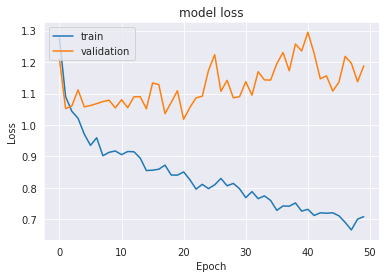

```python
#Plotting Train Loss vs Validation Loss
plt.plot(history5.history['loss'])
plt.plot(history5.history['val_loss'])
plt.title('model loss')
plt.ylabel('Loss')
plt.xlabel('Epoch')
plt.legend(['train', 'validation'], loc='upper left')
plt.show()
```

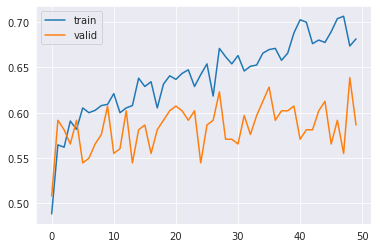

```python
# Capturing learning history per epoch
hist  = pd.DataFrame(history5.history)
hist['epoch'] = history5.epoch

# Plotting accuracy at different epochs
plt.plot(hist['accuracy'])
plt.plot(hist['val_accuracy'])
plt.legend(("train" , "valid") , loc =0)

# Printing results
results = model1.evaluate(X_test, y_test)
```

```python
y_pred=model5.predict(X_test)
y_pred
```

```
array([[4.04871353e-05, 3.72828799e-03, 1.92620277e-01, 9.35906529e-01,
        9.01667595e-01, 2.24719271e-01],
       [1.05487004e-01, 4.07368898e-01, 9.99079823e-01, 9.97585893e-01,
        2.23881930e-01, 2.15607116e-07],
       [5.26745208e-02, 2.42683897e-03, 9.97374952e-01, 9.97387767e-01,
        4.24769789e-01, 1.14228590e-06],
       ...,
       [2.50379071e-06, 1.33376243e-03, 5.02458252e-02, 9.29733336e-01,
        9.60165739e-01, 9.12057817e-01],
       [5.42533994e-01, 9.89972770e-01, 9.99999225e-01, 9.99977171e-01,
        1.91794205e-02, 2.31317873e-12],
       [6.02473676e-01, 9.72025752e-01, 9.96744871e-01, 9.85647202e-01,
        1.12959750e-01, 3.60726017e-06]], dtype=float32)
```

```
Loss and Accuracy on Training data: [0.6676867008209229, 0.7476340532302856]
Loss and Accuracy on Test data: [1.3892204761505127, 0.5245097875595093]

Classification Report:
               precision    recall  f1-score   support

           0       0.00      0.00      0.00         5
           1       0.00      0.00      0.00        11
           2       0.67      0.65      0.66       176
           3       0.48      0.54      0.51       153
           4       0.35      0.30      0.32        60
           5       0.00      0.00      0.00         3

    accuracy                           0.52       408
   macro avg       0.25      0.25      0.25       408
weighted avg       0.52      0.52      0.52       408

Confusion Matrix Chart:
```

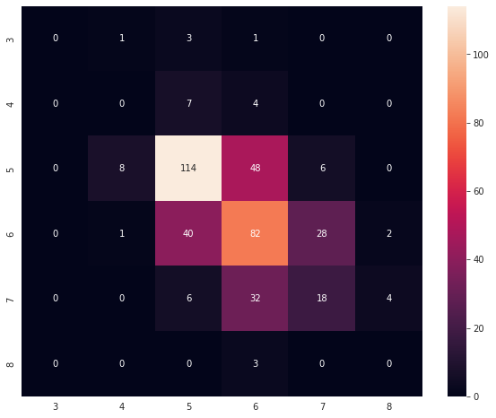

```python
# Classification Accuracy
print('Loss and Accuracy on Training data:',model5.evaluate(X_train, y_train))
print('Loss and Accuracy on Test data:',model5.evaluate(X_test, y_test))
print()

# Classification Report
print("Classification Report:\n",classification_report(y_test.values.argmax(axis=1), y_pred.argmax(axis=1)))

# Confusion Matrix
print("Confusion Matrix Chart:")
cm = confusion_matrix(y_test.values.argmax(axis=1), y_pred.argmax(axis=1), labels=[0,1,2,3,4,5])
df_cm = pd.DataFrame(cm, index = [i for i in ['3','4','5','6','7','8']],
                  columns = [i for i in ['3','4','5','6','7','8']])
plt.figure(figsize = (10,8))
sns.heatmap(df_cm, annot=True, fmt='g')
plt.show()
```